[**Imtiaj.**](https://imtiajiqbalmahfuj.github.io/index.html#top)

# Spatiotemporal Vegetation Condition Index (VCI) Analysis

### Leveraging Google Earth Engine, Cloud-Based Remote Sensing, and Python for Automated Crop Vigor and Stress Mapping

> 🌾 Ingesting over 600+ satellite scenes to isolate seasonal vegetation anomalies and map regional historical crop health comparisons using cloud computing and advanced cartography.

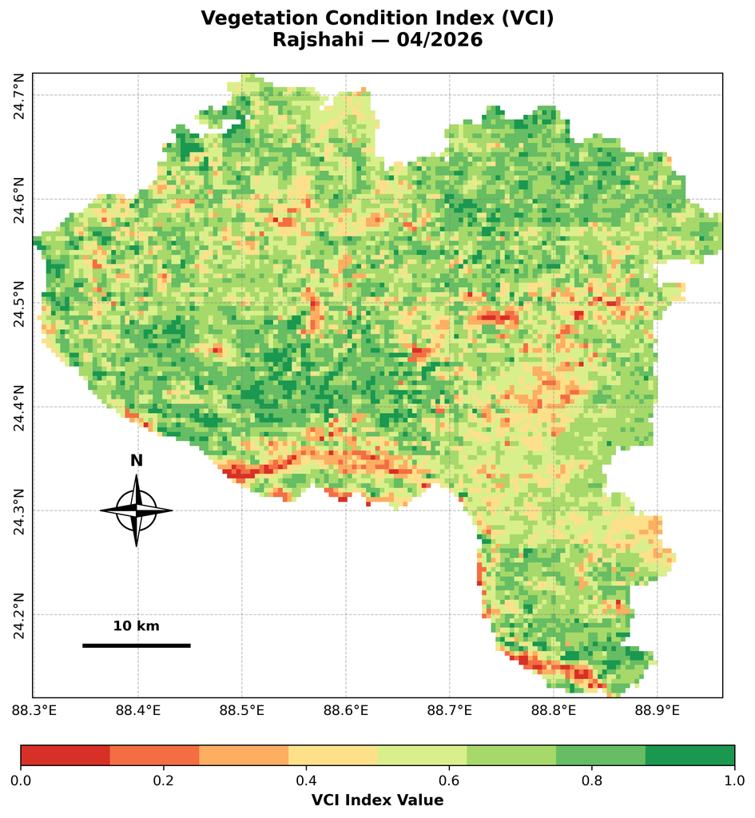

> **Author:** Imtiaj Iqbal Mahfuj

## 📝 Overview

Monitoring regional agricultural productivity and crop health variations poses an enduring challenge for food security and environmental resource management, particularly in highly active agrarian zones like the Rajshahi District of Bangladesh. Traditional field-based observation methods are often labor-intensive, logistically complex, and lack the continuous spatial coverage required for localized macro-level assessments. This project explores **spatial patterns**, integrates **remote sensing datasets**, and applies **geospatial Python tools** to visualize and analyze shifting vegetation condition dynamics. It aims to uncover key insights that support data-driven decision-making for agricultural monitoring, land-use planning, and precision farming interventions.

The primary objective of this analysis is to compute, evaluate, and map the Vegetation Condition Index (VCI) for April 2026. By assessing current Normalized Difference Vegetation Index (NDVI) values against the absolute long-term historical minimums and maximums for the same calendar month, VCI successfully isolates weather-induced crop vigor anomalies from structural ecological variations. This allows for an objective, localized determination of whether regional crop health is performing above or below historical capacity, independent of regular seasonal shifts.

The underlying pipeline shifts heavy computational workflows to the cloud by executing server-side array operations within the Google Earth Engine (GEE) ecosystem via the Python API and `geemap`. After ingesting and preprocessing 603 historical and contemporary scenes from the upgraded MODIS `061` dataset, the resulting spatial data matrices are pulled locally into a Python environment. From there, standard libraries like `Cartopy` and `Matplotlib` assemble a highly polished, publication-ready cartographic layout complete with a custom-drawn geometric compass star and true horizontal scale bar.

This analytical framework provides direct utility to regional planners, climate change researchers, agricultural extension officers, and geospatial data scientists across Bangladesh. By delivering scalable, high-resolution insights into real-time crop health anomalies, the project establishes a robust reproducible workflow for digital agriculture frameworks, index-based crop performance modeling, and sustainable land resource management.

## 🛠️ Tools & Technologies

## ⚙️ Methodology

[output not shown]

## Codes⬇️

```python
import ee
import geemap

# Initialize the Earth Engine library
try:
    ee.Initialize()
except Exception as e:
    ee.Authenticate()
    ee.Initialize()

# Create an interactive map instance
Map = geemap.Map()

# 1. Define Area of Interest (AOI) using FAO GAUL Level 2 for Rajshahi District, Bangladesh
aoi = (ee.FeatureCollection("FAO/GAUL/2015/level2")
       .filter(ee.Filter.eq('ADM0_NAME', 'Bangladesh'))
       .filter(ee.Filter.eq('ADM2_NAME', 'Rajshahi')))
Map.centerObject(aoi, 10)

# 2. MODIS NDVI Data
# Note: Upgraded from '006' to '061' since '006' is deprecated and removed
dataset = ee.ImageCollection('MODIS/061/MOD13Q1').select('NDVI')

# In Python, use .getInfo() to evaluate server-side properties for printing
total_images = dataset.size().getInfo()
print(f"Total number of NDVI Images: {total_images}")

# 3. Scale the MODIS NDVI values (NDVI x 10000 scaled down by 0.0001)
def scale_modis(image):
    scaled = image.divide(10000)
    return scaled.copyProperties(image, ['system:index', 'system:time_start'])

modisScaled = dataset.map(scale_modis)

# 4. Year & Month for specific VCI calculation
year = 2026
month = 4

# Max and Min NDVI for all years but for the selected month
ndvi = modisScaled.filter(ee.Filter.calendarRange(month, month, 'month'))
print("Filtered specific month collection setup completed.")

ndvi_max = ndvi.max().clip(aoi)
ndvi_min = ndvi.min().clip(aoi)

# 5. ndviT is the current NDVI (for a given month & year)
ndviT = (modisScaled
         .filter(ee.Filter.calendarRange(year, year, 'year'))
         .filter(ee.Filter.calendarRange(month, month, 'month'))
         .median()
         .clip(aoi))

# 6. Final calculation of VCI for specified month & year
VCI = ndviT.subtract(ndvi_min).divide(ndvi_max.subtract(ndvi_min)).rename('VCI')

# Define a standard visualization palette for VCI (Red = Drought, Green = Healthy)
vci_viz = {
    'min': 0,
    'max': 1,
    'palette': ['#d73027', '#f46d43', '#fdae61', '#fee08b', '#d9ef8b', '#a6d96a', '#66bd63', '#1a9850']
}

# Add layers to map (False sets visibility to off by default)
Map.addLayer(ndvi_max, {'min': 0, 'max': 1}, 'NDVI_max', False)
Map.addLayer(ndvi_min, {'min': 0, 'max': 1}, 'NDVI_min', False)
Map.addLayer(ndviT, {'min': 0, 'max': 1}, 'NDVIT', False)
Map.addLayer(VCI, vci_viz, 'VCI', True)


# /////////////////////////////////////////
# // All VCI at once (Mapping over collection)
# ////////////////////////////////////////

def calculate_vci_collection(img):
    clipped_img = img.clip(aoi)
    date = ee.Date(clipped_img.get('system:time_start'))
    m = date.get('month')

    # Filter the scaled collection for the specific month across all years
    dataset2 = modisScaled.filter(ee.Filter.calendarRange(m, m, 'month'))
    NDVImin = dataset2.min()
    NDVImax = dataset2.max()

    vci_img = clipped_img.subtract(NDVImin).divide(NDVImax.subtract(NDVImin)).rename('VCI')
    return vci_img.copyProperties(clipped_img, ['system:time_start'])

# Map the function over the scaled dataset
modVCI = modisScaled.map(calculate_vci_collection)

# Add the VCI Image Collection to the map
Map.addLayer(modVCI, vci_viz, 'VCI_IC', True)

# Display the map (Required in Jupyter notebooks / Python environments)
Map
```

```
Total number of NDVI Images: 603
Filtered specific month collection setup completed.
```

```
Extracting spatial bounding box from GEE...
Downloading image data as a NumPy array...
Successfully generated and saved cartographic map layout: VCI_Cartographic_Map_2026_04.png
```

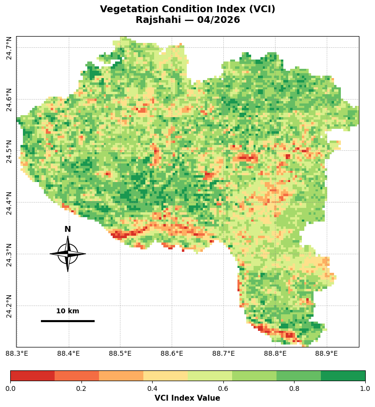

```python
import cartopy.crs as ccrs
import matplotlib.pyplot as plt
import numpy as np
from cartopy.mpl.gridliner import LATITUDE_FORMATTER, LONGITUDE_FORMATTER
from matplotlib.colors import ListedColormap
from matplotlib.patches import Polygon, Circle
import geemap

# ==========================================
# 1. Fetch Spatial Bounds & NumPy Array from GEE (Fixed Background)
# ==========================================

print("Extracting spatial bounding box from GEE...")
aoi_envelope = aoi.geometry().bounds().getInfo()
coords = aoi_envelope['coordinates'][0]
lons = [pt[0] for pt in coords]
lats = [pt[1] for pt in coords]
extent = [min(lons), max(lons), min(lats), max(lats)]

print("Downloading image data as a NumPy array...")
vci_with_nodata = VCI.unmask(-99)
vci_raw = geemap.ee_to_numpy(vci_with_nodata, region=aoi.geometry(), scale=500)
vci_array = np.squeeze(vci_raw)
vci_array = np.where(vci_array == -99, np.nan, vci_array)

# ==========================================
# 2. Setup Plotting and Cartography
# ==========================================

fig, ax = plt.subplots(figsize=(10, 9), subplot_kw={'projection': ccrs.PlateCarree()})
ax.set_extent(extent, crs=ccrs.PlateCarree())

colors = ['#d73027', '#f46d43', '#fdae61', '#fee08b', '#d9ef8b', '#a6d96a', '#66bd63', '#1a9850']
vci_cmap = ListedColormap(colors)

im = ax.imshow(
    vci_array,
    extent=extent,
    cmap=vci_cmap,
    vmin=0,
    vmax=1,
    origin='upper',
    transform=ccrs.PlateCarree()
)

# ==========================================
# 3. Add Cartographic Elements
# ==========================================

# A. Map Title
ax.set_title(f"Vegetation Condition Index (VCI)\nRajshahi — {month:02d}/{year}",
             fontsize=14, pad=20, fontweight='bold')

# B. Geographic Gridlines & Coordinate Labels (Vertical Left Labels)
gl = ax.gridlines(draw_labels=True, linewidth=0.6, color='gray', alpha=0.5, linestyle='--')
gl.top_labels = False
gl.right_labels = False
gl.xformatter = LONGITUDE_FORMATTER
gl.yformatter = LATITUDE_FORMATTER

gl.xlabel_style = {'size': 10}
gl.ylabel_style = {'size': 10, 'rotation': 90, 'va': 'center'}

# C. Colorbar Legend
cbar = fig.colorbar(im, ax=ax, orientation='horizontal', pad=0.06, shrink=0.75, aspect=35)
cbar.set_label('VCI Index Value', fontsize=11, fontweight='semibold')
cbar.set_ticks([0, 0.2, 0.4, 0.6, 0.8, 1.0])

# E. Graphic Scale Bar (Kept exactly where it is)
start_lon = extent[0] + 0.05
start_lat = extent[2] + 0.05
end_lon = start_lon + 0.1  # 0.1 degrees ≈ 10 kilometers

ax.plot([start_lon, end_lon], [start_lat, start_lat], color='black', linewidth=3, transform=ccrs.PlateCarree())
ax.text((start_lon + end_lon)/2, start_lat + 0.012, '10 km',
        transform=ccrs.PlateCarree(), ha='center', va='bottom', fontsize=10, fontweight='bold')

# D. Premium Cartographic Compass Rose (UPDATED: Moved above the scale bar)
# Coordinates use ccrs.PlateCarree() to anchor precisely above the scale lines
cx = start_lon + 0.05          # Centered horizontally over the scale bar footprint
cy = start_lat + 0.13          # Shifted vertically clear of the "10 km" text label
r = 0.035                      # Radius scaled down in degree units for tight grouping
w = r * 0.18                   # Base width of the star points

# Coordinates for the 4 primary directional diamonds split into light/dark facets
facets = [
    # North Point (Right side Dark, Left side Light)
    ([ (cx, cy), (cx, cy + r), (cx + w, cy) ], 'black'),
    ([ (cx, cy), (cx, cy + r), (cx - w, cy) ], 'white'),
    # South Point
    ([ (cx, cy), (cx, cy - r), (cx - w, cy) ], 'black'),
    ([ (cx, cy), (cx, cy - r), (cx + w, cy) ], 'white'),
    # East Point
    ([ (cx, cy), (cx + r, cy), (cx, cy - w) ], 'black'),
    ([ (cx, cy), (cx + r, cy), (cx, cy + w) ], 'white'),
    # West Point
    ([ (cx, cy), (cx - r, cy), (cx, cy + w) ], 'black'),
    ([ (cx, cy), (cx - r, cy), (cx, cy - w) ], 'white'),
]

# Draw the star facets using the map coordinate system
for vertices, face_color in facets:
    poly = Polygon(vertices, facecolor=face_color, edgecolor='black', linewidth=0.8, transform=ccrs.PlateCarree(), zorder=5)
    ax.add_patch(poly)

# Add the central decorative compass ring
compass_ring = Circle((cx, cy), r * 0.55, facecolor='none', edgecolor='black', linewidth=1.2, transform=ccrs.PlateCarree(), zorder=4)
ax.add_patch(compass_ring)

# Top 'N' Text Placement
ax.text(cx, cy + r + 0.005, 'N', transform=ccrs.PlateCarree(), ha='center', va='bottom', fontsize=12, fontweight='bold', zorder=5)

# ==========================================
# 4. Save and Export Image Asset
# ==========================================
plt.tight_layout()
output_filename = f"VCI_Cartographic_Map_{year}_{month:02d}.png"

plt.savefig(output_filename, dpi=300, bbox_inches='tight', facecolor='white')
print(f"Successfully generated and saved cartographic map layout: {output_filename}")

plt.show()
```

*Caption: Advanced cartographic map layout visualizing the Vegetation Condition Index (VCI) across Rajshahi District, Bangladesh, for April 2026. The diverging color ramp distinguishes regions experiencing lower relative vegetation condition (red) from highly healthy biomass development (green).*

## ❓ Why this project?

- **Legacy Code & Deprecation Fixes:** Many legacy geospatial scripts rely on the MODIS `006` product tier, which has been fully deprecated and removed from earth science servers. This workflow adopts the updated `061` dataset tier to guarantee long-term reproducibility.
- **Isolating Climate Anomaly Signals:** Raw NDVI maps can be misleading because they display natural structural differences across varying land covers. By measuring current conditions exclusively against historical extrema for that exact calendar month, VCI isolates genuine climatic anomalies from regular seasonal shifts.
- **Publication-Quality Automation:** While interactive maps are useful for data exploration, peer-reviewed publications and formal institutional reports demand precise, static cartographic elements (such as explicit grid projections, exact scale bars, and standardized North indicators) built programmatically to prevent manual rendering errors.

## ✨ Features

- **Scalable Spatial Filtering:** Effortlessly re-targets any global administrative zone by adjusting the FAO GAUL collection constraints.
- **Server-to-Local Array Transfer:** Streamlines cloud-based calculation with specialized local data structures by transitioning Earth Engine image properties to responsive local NumPy arrays.
- **Premium Cartographic Controls:** Includes a fully automated, multi-faceted geometric compass rose vector script that anchors perfectly regardless of coordinate changes.
- **Exportable Plot Assets:** Automatically outputs high-fidelity visuals (PNG at 300 DPI) configured with tight bounding box parameters ready for deployment in presentations or papers.

## 📎 Links

- 🔗 [See more on LinkedIn](https://linkedin.com/in/imtiajiqbalmahfuj)

## 🔖 Tags

`GIS` `Remote Sensing` `Geospatial Python` `Python` `GEE` `Spatial Data-Science` `Vegetation Condition Index` `MODIS` `Agricultural Analytics`

## 📌 Credits & Shoutouts

- 👨‍💻 **Author:** [Imtiaj Iqbal Mahfuj](https://imtiajiqbalmahfuj.github.io/)
- 🙌 **Inspiration:** Special thanks to the Google Earth Engine and open-source Geospatial Python Communities for active development on packages like `geemap` and `cartopy`.
- 🗂️ **Data Sources:** NASA LP DAAC (Land Processes Distributed Active Archive Center) via Google Earth Engine Data Catalog, and FAO GAUL 2015 Global Administrative Unit Layers.

## 💬 Connect with Me

📧 Email: imtiajiqbal.ruet@gmail.com  
🌐 Portfolio: https://imtiajiqbalmahfuj.github.io/